# Task3

Osipov Denis

2023-03-15

# Линейная регрессия

```r
library(reticulate)
path_to_python <- "/home/jinedl/prak/sem6/sem6/bin/python"
use_python(path_to_python)
library(LambertW)
```

```python
import numpy as np
import pandas as pd
```

## Подготовка данных

Вариант 5

```python
data = pd.read_csv('AUDUSD.csv')
data = data[['<DATE>', '<CLOSE>']].copy()
data.columns = ['DATE', 'AUDUSD']
data
```

```
##          DATE   AUDUSD
## 0    05/02/20  0.67509
## 1    06/02/20  0.67311
## 2    07/02/20  0.66720
## 3    09/02/20  0.66684
## 4    10/02/20  0.66890
## ..        ...      ...
## 623  01/02/22  0.71327
## 624  02/02/22  0.71203
## 625  03/02/22  0.71423
## 626  04/02/22  0.70730
## 627  06/02/22  0.70792
##
## [628 rows x 2 columns]
```

```python
assets = ['SANDP-500', 'comex.GC', 'ICE.BRN', 'CHFUSD', 'EURUSD', 'NYMEX.PL', 'USDNOK']
for a in assets:
  asset = pd.read_csv(a+'.csv')
  ticker = asset.loc[1, '<TICKER>']
  asset = asset[['<DATE>', '<CLOSE>']].copy()
  asset.columns = ['DATE', ticker]
  data = data.merge(asset, how='inner', on='DATE')
data
```

```
##          DATE   AUDUSD  SANDP-500  ...   EURUSD  NYMEX.PL   USDNOK
## 0    05/02/20  0.67509    3334.69  ...  1.10004     984.1  9.20758
## 1    06/02/20  0.67311    3345.78  ...  1.09807     969.2  9.21950
## 2    07/02/20  0.66720    3327.71  ...  1.09440     969.9  9.29280
## 3    10/02/20  0.66890    3352.09  ...  1.09101     965.2  9.28682
## 4    11/02/20  0.67174    3357.75  ...  1.09189     972.0  9.24290
## ..        ...      ...        ...  ...      ...       ...      ...
## 481  31/01/22  0.70670    4515.55  ...  1.12291    1022.2  8.90320
## 482  01/02/22  0.71327    4546.54  ...  1.12728    1028.7  8.82890
## 483  02/02/22  0.71203    4589.38  ...  1.12994    1035.3  8.81670
## 484  03/02/22  0.71423    4477.44  ...  1.14356    1035.1  8.71797
## 485  04/02/22  0.70730    4500.53  ...  1.14460    1026.4  8.78950
##
## [486 rows x 9 columns]
```

```python
data = np.log(np.array(data.drop('DATE', axis=1)))
data = data[1:] - data[:-1]
data = pd.DataFrame(data, columns=['AUDUSD']+assets)
data
```

```
##        AUDUSD  SANDP-500  comex.GC  ...    EURUSD  NYMEX.PL    USDNOK
## 0   -0.002937   0.003320  0.008061  ... -0.001792 -0.015257  0.001294
## 1   -0.008819  -0.005415  0.002863  ... -0.003348  0.000722  0.007919
## 2    0.002545   0.007300 -0.001081  ... -0.003102 -0.004858 -0.000644
## 3    0.004237   0.001687 -0.001082  ...  0.000806  0.007020 -0.004741
## 4   -0.000849   0.006442  0.004004  ... -0.004056 -0.008265 -0.000149
## ..        ...        ...       ...  ...       ...       ...       ...
## 480  0.010526   0.018710  0.005515  ...  0.007338  0.010424 -0.008344
## 481  0.009254   0.006840 -0.001112  ...  0.003884  0.006339 -0.008380
## 482 -0.001740   0.009378  0.004938  ...  0.002357  0.006395 -0.001383
## 483  0.003085  -0.024693  0.000221  ...  0.011982 -0.000193 -0.011261
## 484 -0.009750   0.005144  0.000830  ...  0.000909 -0.008441  0.008171
##
## [485 rows x 8 columns]
```

```python
filename = 'data.csv'
data.to_csv(filename, index=False)
```

```r
Data <- read.csv("data.csv",sep=",")
head(Data)
```

```
##          AUDUSD    SANDP.500      comex.GC      ICE.BRN        CHFUSD
## 1 -0.0029372518  0.003320129  0.0080614640 -0.008310798 -0.0014614900
## 2 -0.0088189125 -0.005415471  0.0028634171 -0.011311925 -0.0032228164
## 3  0.0025447211  0.007299652 -0.0010807719 -0.020389956  0.0006062918
## 4  0.0042367888  0.001687075 -0.0010819412  0.015792246  0.0015434062
## 5 -0.0008489028  0.006441868  0.0040036913  0.038156695 -0.0020518841
## 6  0.0009679894 -0.001631773  0.0005706496  0.001772736 -0.0011352294
##          EURUSD      NYMEX.PL        USDNOK
## 1 -0.0017924494 -0.0152565290  0.0012937483
## 2 -0.0033478254  0.0007219845  0.0079191006
## 3 -0.0031023952 -0.0048576396 -0.0006437161
## 4  0.0008062669  0.0070204707 -0.0047405014
## 5 -0.0040562423 -0.0082645098 -0.0001493149
## 6 -0.0031683195  0.0083673852  0.0011225615
```

## Регрессионная модель

Построим регрессионую модель от всех предикторов с константой

```r
regr <- lm(Data$AUDUSD ~ Data$SANDP.500 + Data$comex.GC + Data$ICE.BRN + Data$CHFUSD + Data$EURUSD + Data$NYMEX + Data$USDNOK, data=Data)
summary(regr)
```

```
##
## Call:
## lm(formula = Data$AUDUSD ~ Data$SANDP.500 + Data$comex.GC + Data$ICE.BRN +
##     Data$CHFUSD + Data$EURUSD + Data$NYMEX + Data$USDNOK, data = Data)
##
## Residuals:
##        Min         1Q     Median         3Q        Max
## -0.0223311 -0.0025123 -0.0001418  0.0025009  0.0232182
##
## Coefficients:
##                  Estimate Std. Error t value Pr(>|t|)
## (Intercept)    -1.176e-05  2.005e-04  -0.059 0.953247
## Data$SANDP.500  4.494e-02  1.660e-02   2.707 0.007043 **
## Data$comex.GC   5.346e-02  2.175e-02   2.458 0.014315 *
## Data$ICE.BRN   -7.003e-03  7.601e-03  -0.921 0.357369
## Data$CHFUSD     1.756e-02  8.225e-02   0.214 0.830991
## Data$EURUSD     4.691e-01  9.230e-02   5.082 5.37e-07 ***
## Data$NYMEX      4.566e-02  1.172e-02   3.894 0.000113 ***
## Data$USDNOK    -2.788e-01  3.495e-02  -7.977 1.12e-14 ***
## ---
## Signif. codes:  0 '***' 0.001 '**' 0.01 '*' 0.05 '.' 0.1 ' ' 1
##
## Residual standard error: 0.004406 on 477 degrees of freedom
## Multiple R-squared:  0.604,  Adjusted R-squared:  0.5981
## F-statistic: 103.9 on 7 and 477 DF,  p-value: < 2.2e-16
```

- Константа - незначима, т.к. не отвергаем гипотезу о её незначимости (p-value > 0.05)
- SANDP.500 - значимый предиктор, т.к. отвергаем гипотезу о его незначимости (p-value < 0.05)
- comex.GC - значимый предиктор, т.к. отвергаем гипотезу о его незначимости (p-value < 0.05)
- ICE.BRN - незначимый предиктор, т.к. не отвергаем гипотезу о его незначимости (p-value > 0.05)
- CHFUSD - незначимый предиктор, т.к. не отвергаем гипотезу о его незначимости (p-value > 0.05)
- EURUSD - значимый предиктор, т.к. отвергаем гипотезу о его незначимости (p-value < 0.05)
- NYMEX - значимый предиктор, т.к. отвергаем гипотезу о его незначимости (p-value < 0.05)
- USDNOK - значимый предиктор, т.к. отвергаем гипотезу о его незначимости (p-value < 0.05)

Переоценим регрессионую модель только для значимых переменных

```r
regr <- lm(Data$AUDUSD ~ Data$SANDP.500 + Data$comex.GC + Data$EURUSD + Data$NYMEX + Data$USDNOK - 1, data=Data)
summary(regr)
```

```
##
## Call:
## lm(formula = Data$AUDUSD ~ Data$SANDP.500 + Data$comex.GC + Data$EURUSD +
##     Data$NYMEX + Data$USDNOK - 1, data = Data)
##
## Residuals:
##        Min         1Q     Median         3Q        Max
## -0.0226838 -0.0026021 -0.0001376  0.0024636  0.0226496
##
## Coefficients:
##                Estimate Std. Error t value Pr(>|t|)
## Data$SANDP.500  0.04208    0.01630   2.581  0.01014 *
## Data$comex.GC   0.05489    0.02134   2.573  0.01039 *
## Data$EURUSD     0.49987    0.06138   8.144 3.32e-15 ***
## Data$NYMEX      0.04471    0.01164   3.840  0.00014 ***
## Data$USDNOK    -0.26766    0.03288  -8.141 3.41e-15 ***
## ---
## Signif. codes:  0 '***' 0.001 '**' 0.01 '*' 0.05 '.' 0.1 ' ' 1
##
## Residual standard error: 0.004396 on 480 degrees of freedom
## Multiple R-squared:  0.6032, Adjusted R-squared:  0.5991
## F-statistic:   146 on 5 and 480 DF,  p-value: < 2.2e-16
```

## Исследовать остатки на некоррелированность и по возможности исследовать их распределение

#### Исследование на распределение

Построим гистограмму остатков

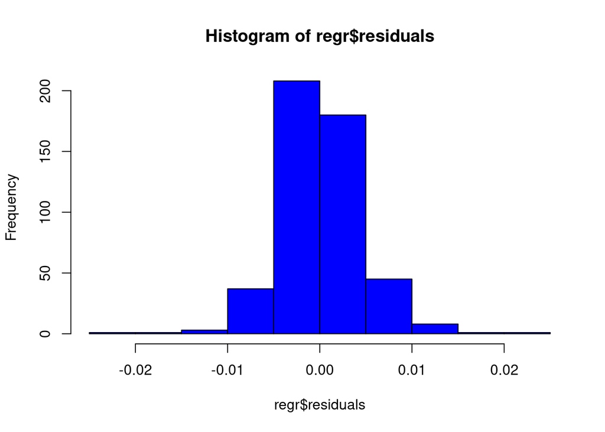

```r
hist(regr$residuals, col = "blue")
```

Стандартизируем остатки

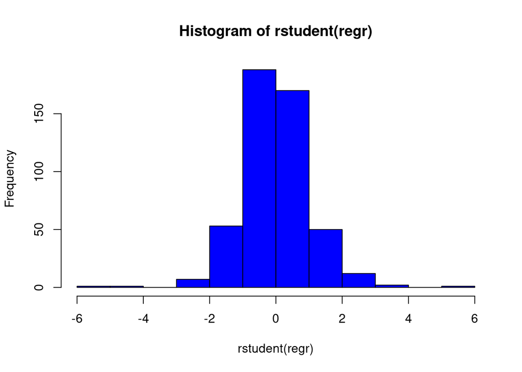

```r
hist(rstudent(regr), col = "blue")
```

Глядя на гистограммы, можно предположить, что остатки распределены по стьюденту.

Построим Q-Q Plot остатков

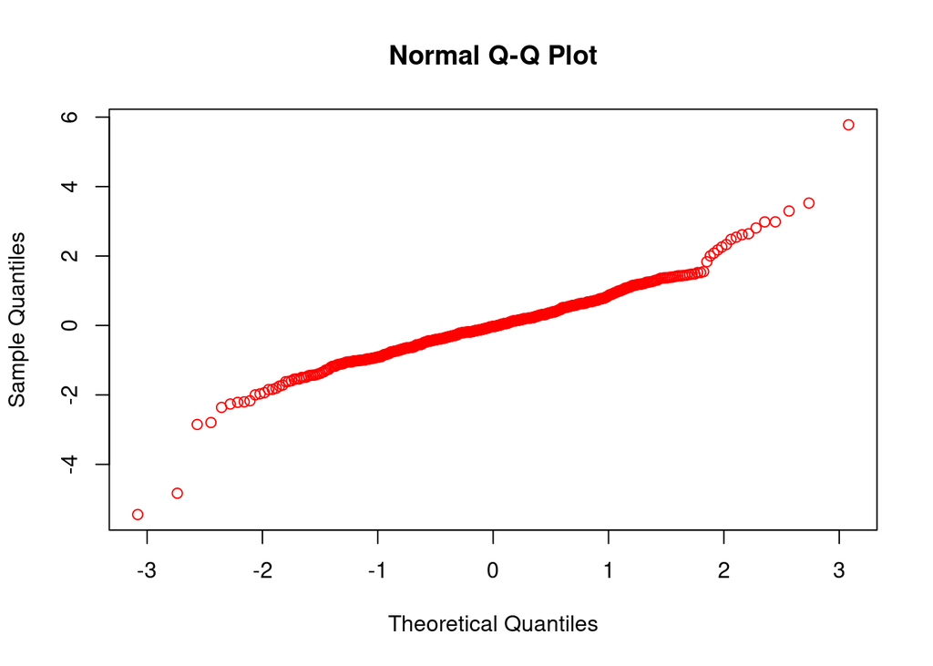

```r
qqnorm(rstudent(regr), col="red")
```

Судя по хвостам, остатки распределены по стьюденту.

Применим тест Колмогорова-Смирнова для проверки распределения остатков (распределены ли они по стьюденту?)

```r
ks_test_t(rstudent(regr))
```

```
##
##  One-sample Kolmogorov-Smirnov test student-t with df=4.47,
##  location=-0.02, scale=0.75
##
## data:  rstudent(regr)
## D = 0.020939, p-value = 0.9836
## alternative hypothesis: two-sided
```

Остатки распределены по Стьюденту

#### Исследование на коррелированность

Найдём ACF остатков

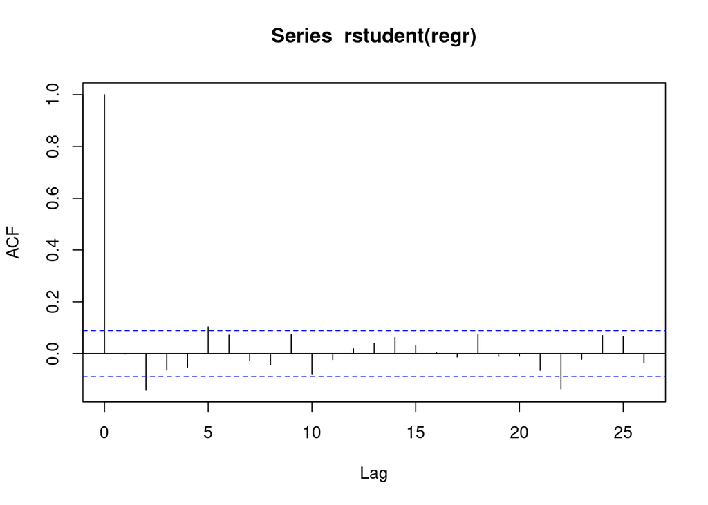

```r
acf(rstudent(regr))
```

Остатки коррелированы

В этом случае оценка максимального правдоподобия не совпадает с оценкой наименьших квадратов.